# Fallstudie 1

Sanja Perovic, Julia Zerrweck

7/29/2020

# Data preparation

## a

```r
library(readr)
df <- read_csv("responses.csv")
df
```

```
## # A tibble: 1,010 x 150
##    Music `Slow songs or … Dance  Folk Country `Classical musi… Musical   Pop
##    <dbl>            <dbl> <dbl> <dbl>   <dbl>            <dbl>   <dbl> <dbl>
##  1     5                3     2     1       2                2       1     5
##  2     4                4     2     1       1                1       2     3
##  3     5                5     2     2       3                4       5     3
##  4     5                3     2     1       1                1       1     2
##  5     5                3     4     3       2                4       3     5
##  6     5                3     2     3       2                3       3     2
##  7     5                5     5     3       1                2       2     5
##  8     5                3     3     2       1                2       2     4
##  9     5                3     3     1       1                2       4     3
## 10     5                3     2     5       2                2       5     3
## # … with 1,000 more rows, and 142 more variables: Rock <dbl>, `Metal or
## #   Hardrock` <dbl>, Punk <dbl>, `Hiphop, Rap` <dbl>, `Reggae, Ska` <dbl>,
## #   `Swing, Jazz` <dbl>, `Rock n roll` <dbl>, Alternative <dbl>, Latino <dbl>,
## #   `Techno, Trance` <dbl>, Opera <dbl>, Movies <dbl>, Horror <dbl>,
## #   Thriller <dbl>, Comedy <dbl>, Romantic <dbl>, `Sci-fi` <dbl>, War <dbl>,
## #   `Fantasy/Fairy tales` <dbl>, Animated <dbl>, Documentary <dbl>,
## #   Western <dbl>, Action <dbl>, History <dbl>, Psychology <dbl>,
## #   Politics <dbl>, Mathematics <dbl>, Physics <dbl>, Internet <dbl>, PC <dbl>,
## #   `Economy Management` <dbl>, Biology <dbl>, Chemistry <dbl>, Reading <dbl>,
## #   Geography <dbl>, `Foreign languages` <dbl>, Medicine <dbl>, Law <dbl>,
## #   Cars <dbl>, `Art exhibitions` <dbl>, Religion <dbl>, `Countryside,
## #   outdoors` <dbl>, Dancing <dbl>, `Musical instruments` <dbl>, Writing <dbl>,
## #   `Passive sport` <dbl>, `Active sport` <dbl>, Gardening <dbl>,
## #   Celebrities <dbl>, Shopping <dbl>, `Science and technology` <dbl>,
## #   Theatre <dbl>, `Fun with friends` <dbl>, `Adrenaline sports` <dbl>,
## #   Pets <dbl>, Flying <dbl>, Storm <dbl>, Darkness <dbl>, Heights <dbl>,
## #   Spiders <dbl>, Snakes <dbl>, Rats <dbl>, Ageing <dbl>, `Dangerous
## #   dogs` <dbl>, `Fear of public speaking` <dbl>, Smoking <chr>, Alcohol <chr>,
## #   `Healthy eating` <dbl>, `Daily events` <dbl>, `Prioritising
## #   workload` <dbl>, `Writing notes` <dbl>, Workaholism <dbl>, `Thinking
## #   ahead` <dbl>, `Final judgement` <dbl>, Reliability <dbl>, `Keeping
## #   promises` <dbl>, `Loss of interest` <dbl>, `Friends versus money` <dbl>,
## #   Funniness <dbl>, Fake <dbl>, `Criminal damage` <dbl>, `Decision
## #   making` <dbl>, Elections <dbl>, `Self-criticism` <dbl>, `Judgment
## #   calls` <dbl>, Hypochondria <dbl>, Empathy <dbl>, `Eating to survive` <dbl>,
## #   Giving <dbl>, `Compassion to animals` <dbl>, `Borrowed stuff` <dbl>,
## #   Loneliness <dbl>, `Cheating in school` <dbl>, Health <dbl>, `Changing the
## #   past` <dbl>, God <dbl>, Dreams <dbl>, Charity <dbl>, `Number of
## #   friends` <dbl>, Punctuality <chr>, …
```

```r
library(tidyr)
df <- drop_na(df)
df
```

```
## # A tibble: 674 x 150
##    Music `Slow songs or … Dance  Folk Country `Classical musi… Musical   Pop
##    <dbl>            <dbl> <dbl> <dbl>   <dbl>            <dbl>   <dbl> <dbl>
##  1     5                3     2     1       2                2       1     5
##  2     4                4     2     1       1                1       2     3
##  3     5                5     2     2       3                4       5     3
##  4     5                3     4     3       2                4       3     5
##  5     5                3     2     3       2                3       3     2
##  6     5                5     5     3       1                2       2     5
##  7     5                3     3     2       1                2       2     4
##  8     5                3     2     5       2                2       5     3
##  9     5                3     3     2       1                2       3     4
## 10     5                3     1     1       1                4       1     2
## # … with 664 more rows, and 142 more variables: Rock <dbl>, `Metal or
## #   Hardrock` <dbl>, Punk <dbl>, `Hiphop, Rap` <dbl>, `Reggae, Ska` <dbl>,
## #   `Swing, Jazz` <dbl>, `Rock n roll` <dbl>, Alternative <dbl>, Latino <dbl>,
## #   `Techno, Trance` <dbl>, Opera <dbl>, Movies <dbl>, Horror <dbl>,
## #   Thriller <dbl>, Comedy <dbl>, Romantic <dbl>, `Sci-fi` <dbl>, War <dbl>,
## #   `Fantasy/Fairy tales` <dbl>, Animated <dbl>, Documentary <dbl>,
## #   Western <dbl>, Action <dbl>, History <dbl>, Psychology <dbl>,
## #   Politics <dbl>, Mathematics <dbl>, Physics <dbl>, Internet <dbl>, PC <dbl>,
## #   `Economy Management` <dbl>, Biology <dbl>, Chemistry <dbl>, Reading <dbl>,
## #   Geography <dbl>, `Foreign languages` <dbl>, Medicine <dbl>, Law <dbl>,
## #   Cars <dbl>, `Art exhibitions` <dbl>, Religion <dbl>, `Countryside,
## #   outdoors` <dbl>, Dancing <dbl>, `Musical instruments` <dbl>, Writing <dbl>,
## #   `Passive sport` <dbl>, `Active sport` <dbl>, Gardening <dbl>,
## #   Celebrities <dbl>, Shopping <dbl>, `Science and technology` <dbl>,
## #   Theatre <dbl>, `Fun with friends` <dbl>, `Adrenaline sports` <dbl>,
## #   Pets <dbl>, Flying <dbl>, Storm <dbl>, Darkness <dbl>, Heights <dbl>,
## #   Spiders <dbl>, Snakes <dbl>, Rats <dbl>, Ageing <dbl>, `Dangerous
## #   dogs` <dbl>, `Fear of public speaking` <dbl>, Smoking <chr>, Alcohol <chr>,
## #   `Healthy eating` <dbl>, `Daily events` <dbl>, `Prioritising
## #   workload` <dbl>, `Writing notes` <dbl>, Workaholism <dbl>, `Thinking
## #   ahead` <dbl>, `Final judgement` <dbl>, Reliability <dbl>, `Keeping
## #   promises` <dbl>, `Loss of interest` <dbl>, `Friends versus money` <dbl>,
## #   Funniness <dbl>, Fake <dbl>, `Criminal damage` <dbl>, `Decision
## #   making` <dbl>, Elections <dbl>, `Self-criticism` <dbl>, `Judgment
## #   calls` <dbl>, Hypochondria <dbl>, Empathy <dbl>, `Eating to survive` <dbl>,
## #   Giving <dbl>, `Compassion to animals` <dbl>, `Borrowed stuff` <dbl>,
## #   Loneliness <dbl>, `Cheating in school` <dbl>, Health <dbl>, `Changing the
## #   past` <dbl>, God <dbl>, Dreams <dbl>, Charity <dbl>, `Number of
## #   friends` <dbl>, Punctuality <chr>, …
```

```r
library(tidyverse)
glimpse(df)
```

```
## Rows: 674
## Columns: 150
## $ Music                            <dbl> 5, 4, 5, 5, 5, 5, 5, 5, 5, 5, 5, 5, …
## $ `Slow songs or fast songs`       <dbl> 3, 4, 5, 3, 3, 5, 3, 3, 3, 3, 3, 3, …
## $ Dance                            <dbl> 2, 2, 2, 4, 2, 5, 3, 2, 3, 1, 1, 5, …
## $ Folk                             <dbl> 1, 1, 2, 3, 3, 3, 2, 5, 2, 1, 2, 3, …
## $ Country                          <dbl> 2, 1, 3, 2, 2, 1, 1, 2, 1, 1, 1, 2, …
## $ `Classical music`                <dbl> 2, 1, 4, 4, 3, 2, 2, 2, 2, 4, 4, 1, …
## $ Musical                          <dbl> 1, 2, 5, 3, 3, 2, 2, 5, 3, 1, 3, 5, …
## $ Pop                              <dbl> 5, 3, 3, 5, 2, 5, 4, 3, 4, 2, 3, 5, …
## $ Rock                             <dbl> 5, 5, 5, 3, 5, 3, 5, 5, 3, 5, 5, 2, …
## $ `Metal or Hardrock`              <dbl> 1, 4, 3, 1, 5, 1, 1, 2, 2, 1, 4, 1, …
## $ Punk                             <dbl> 1, 4, 4, 2, 3, 1, 2, 3, 1, 1, 2, 1, …
## $ `Hiphop, Rap`                    <dbl> 1, 1, 1, 5, 4, 3, 3, 2, 3, 1, 3, 2, …
## $ `Reggae, Ska`                    <dbl> 1, 3, 4, 3, 3, 1, 2, 4, 2, 1, 1, 1, …
```

[output cut: 137 more lines]

## b

```r
library(dplyr)
df_1 <- select (df, c("Height",
                      "Weight",
                      "Gender"))
df_1
```

```
## # A tibble: 674 x 3
##    Height Weight Gender
##     <dbl>  <dbl> <chr>
##  1    163     48 female
##  2    163     58 female
##  3    176     67 female
##  4    170     59 female
##  5    186     77 male
##  6    177     50 female
##  7    184     90 male
##  8    174     60 female
##  9    175     60 female
## 10    176     60 female
## # … with 664 more rows
```

## c

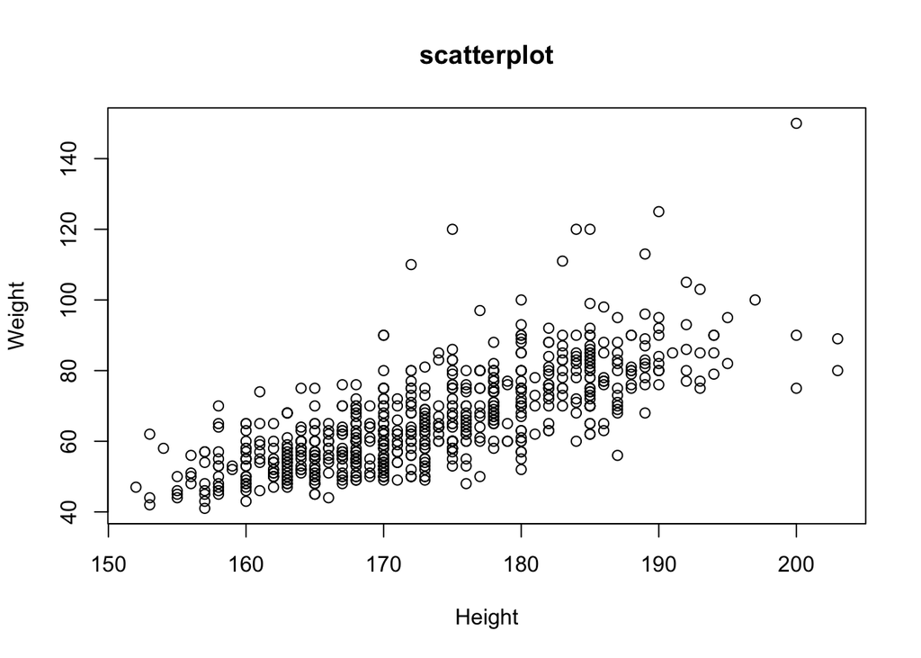

```r
library(ggplot2)
x <- df_1$Height
y <- df_1$Weight

  plot (
    x, y, main = "scatterplot",
    xlab = "Height",
    ylab = "Weight")
```

## d

```r
x <- select (df_1, c("Height",
                     "Weight"))

x$Height_sc <- scale (x$Height,
                      scale =TRUE)

x$Weight_sc <- scale (x$Weight,
                      scale =TRUE)

x_std <- select(x, c("Height_sc",
                     "Weight_sc"))
x_std
```

```
## # A tibble: 674 x 2
##    Height_sc[,1] Weight_sc[,1]
##            <dbl>         <dbl>
##  1       -1.10         -1.30
##  2       -1.10         -0.584
##  3        0.272         0.0635
##  4       -0.361        -0.512
##  5        1.33          0.783
##  6        0.378        -1.16
##  7        1.12          1.72
##  8        0.0612       -0.440
##  9        0.167        -0.440
## 10        0.272        -0.440
## # … with 664 more rows
```

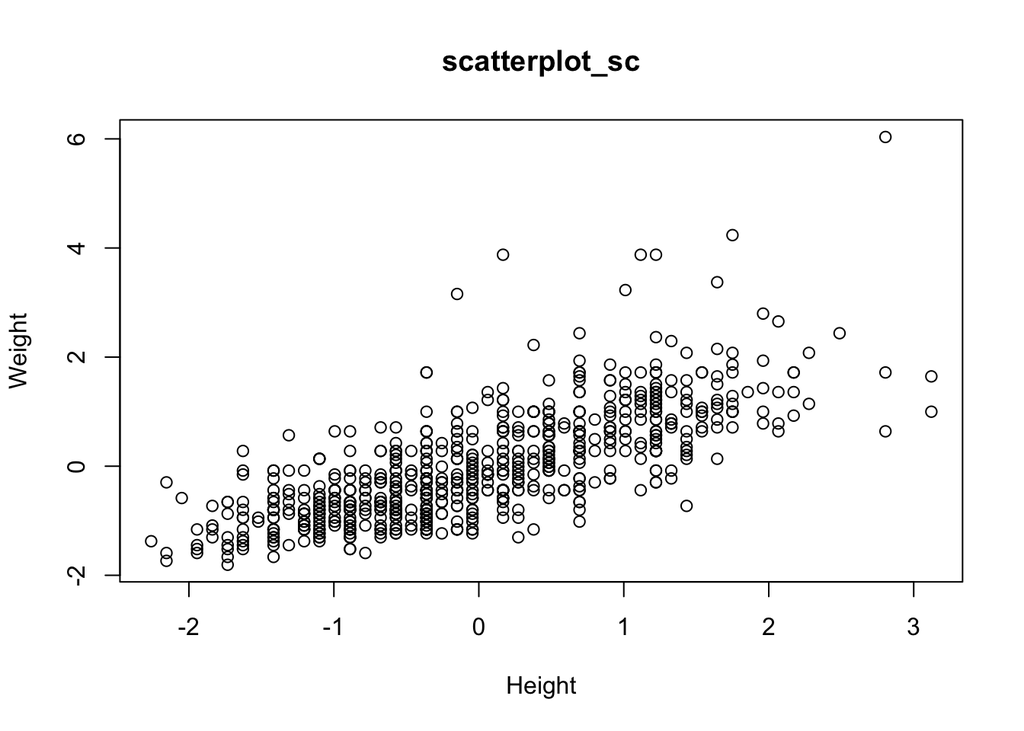

```r
x <- x_std$Height_sc
y <- x_std$Weight_sc

  plot (
    x, y, main = "scatterplot_sc",
    xlab = "Height",
    ylab = "Weight")
```

## e

Um Werte, die sich in unterschiedlichen Wertebereichen befinden, vergleichen zu können muss der Mittelwert auf 0 und die Standardabweichung auf 1 gesetzt werden. Die Abstände zwischen den Werten machen es sonst unmöglich diese direkt vergleichen zu können. Wir können in unserem Fall erkennen, wie sich die Werte auf den x&y-Achsen deutlich vermindert haben.

# k-Means

## a

```r
set.seed(123)
x_cluster <- kmeans(x_std, 2, nstart = 8)
x_cluster
```

```
## K-means clustering with 2 clusters of sizes 413, 261
##
## Cluster means:
##    Height_sc  Weight_sc
## 1 -0.6261475 -0.6071273
## 2  0.9908005  0.9607033
##
## Clustering vector:
##   [1] 1 1 1 1 2 1 2 1 1 1 1 1 1 1 2 2 2 2 1 1 1 1 2 1 2 2 1 1 2 1 1 1 1 1 2 2 1
##  [38] 1 1 1 1 1 1 1 1 1 2 2 1 2 1 2 2 1 1 2 2 2 2 2 1 1 1 2 1 1 2 1 1 1 1 2 2 2
##  [75] 2 1 1 2 2 2 2 1 1 2 1 1 1 1 1 1 1 2 2 1 2 1 1 1 1 2 2 1 1 1 2 2 1 1 2 1 1
## [112] 2 1 2 1 2 1 1 2 1 2 1 1 2 1 2 2 2 1 1 2 1 2 1 2 1 1 1 1 2 2 1 2 1 1 1 1 2
## [149] 1 1 1 1 1 1 1 1 2 2 2 1 1 1 1 1 1 2 1 1 1 1 1 1 1 2 1 1 1 2 1 1 1 1 1 1 1
## [186] 2 2 1 1 1 1 1 1 1 2 1 2 1 1 2 2 2 2 1 2 1 1 1 1 2 2 1 1 2 2 1 1 2 1 1 1 2
## [223] 1 1 1 2 2 1 1 1 2 1 2 1 1 1 2 1 1 1 2 1 2 1 1 2 1 1 1 2 2 2 2 1 1 2 1 2 1
## [260] 1 2 2 1 1 2 1 1 1 1 1 2 2 1 1 1 1 2 1 1 2 2 1 1 2 2 2 1 1 1 1 1 2 1 1 2 1
## [297] 1 1 1 1 1 1 1 1 2 1 1 2 2 1 2 1 1 2 2 1 1 1 1 1 2 1 1 2 1 2 1 1 2 2 1 2 2
## [334] 1 1 1 1 1 2 2 1 2 1 2 1 1 1 1 2 1 1 1 1 1 1 1 2 2 1 2 2 2 2 2 1 2 1 1 1 2
## [371] 2 1 2 1 2 1 1 2 1 2 1 2 2 2 2 1 1 2 1 1 1 2 2 2 1 1 2 1 1 2 1 2 2 1 2 2 2
## [408] 1 1 1 2 1 1 2 1 2 2 2 1 1 1 2 2 1 2 1 1 2 1 2 2 1 1 1 1 2 2 1 2 1 2 2 2 1
## [445] 2 2 1 2 1 2 1 1 1 1 2 1 1 1 1 1 1 1 2 1 2 2 1 1 1 2 1 1 2 1 1 1 1 2 2 1 1
## [482] 1 1 1 1 1 1 2 2 1 2 1 1 2 1 2 2 1 1 1 1 1 2 1 2 2 1 1 2 1 1 1 2 1 2 1 2 2
## [519] 1 2 2 1 1 1 1 1 1 1 1 1 1 1 2 2 1 2 2 2 1 2 2 1 2 2 1 1 1 2 2 2 2 2 1 2 1
## [556] 2 1 1 2 1 2 1 1 1 1 2 2 2 2 1 1 1 2 1 2 1 2 2 2 1 2 2 2 2 2 2 2 1 1 1 2 1
## [593] 2 2 2 2 1 1 1 1 2 1 1 2 1 2 2 2 1 2 1 1 1 1 1 1 1 1 1 1 2 1 1 1 1 2 1 1 1
## [630] 2 1 1 1 1 1 1 1 1 1 1 1 1 2 1 1 2 2 2 1 2 2 2 1 2 1 2 1 2 1 1 1 2 2 2 1 2
## [667] 1 1 1 1 1 2 1 2
##
## Within cluster sum of squares by cluster:
## [1] 252.6333 282.1023
##  (between_SS / total_SS =  60.3 %)
##
## Available components:
##
## [1] "cluster"      "centers"      "totss"        "withinss"     "tot.withinss"
## [6] "betweenss"    "size"         "iter"         "ifault"
```

## b

Unser Verfahren startet von 8 verschiedenen Starting Points. Denn je höher der Starting Point desto eher können wir ein stabileres Resultat erhalten. kMeans läuft nämlich 8 Mal in unserem Fall durch und kann aus diesen 8 Resultaten das beste Ergebnis abliefern.

## c

total SS = Summe der Quadrate between SS = Summe der quadrierten Abstände der Quadrate

## d

```r
x_std$gender_kmeans <- as.factor(x_cluster$cluster)
x_std
```

```
## # A tibble: 674 x 3
##    Height_sc[,1] Weight_sc[,1] gender_kmeans
##            <dbl>         <dbl> <fct>
##  1       -1.10         -1.30   1
##  2       -1.10         -0.584  1
##  3        0.272         0.0635 1
##  4       -0.361        -0.512  1
##  5        1.33          0.783  2
##  6        0.378        -1.16   1
##  7        1.12          1.72   2
##  8        0.0612       -0.440  1
##  9        0.167        -0.440  1
## 10        0.272        -0.440  1
## # … with 664 more rows
```

## e

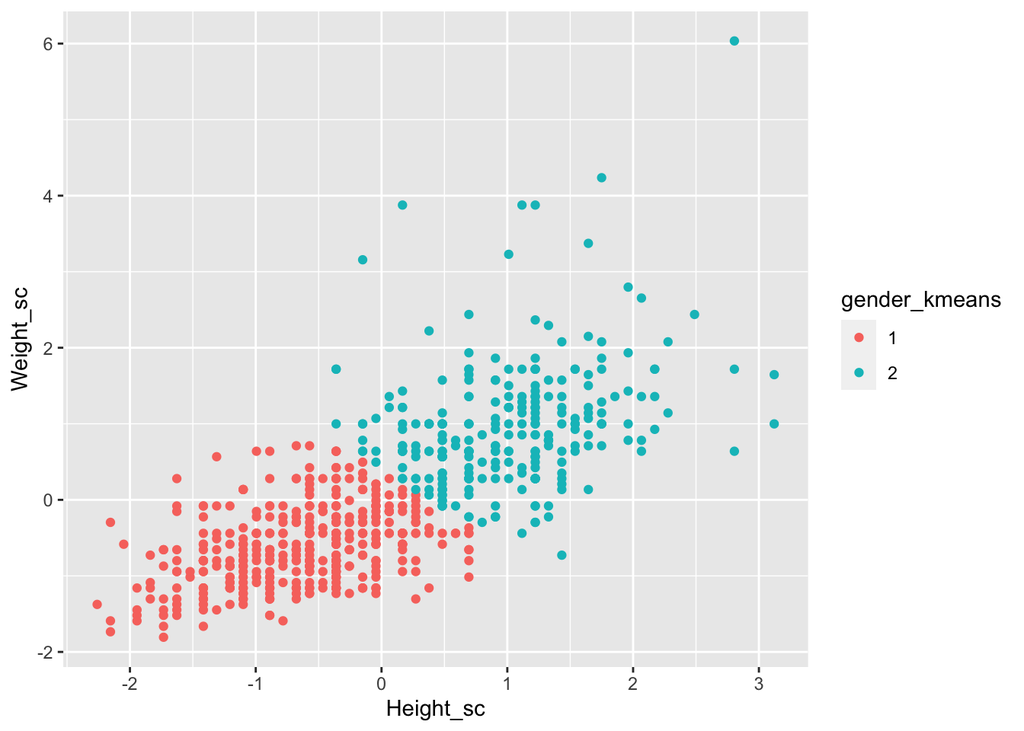

```r
ggplot(x_std,
       aes(Height_sc, Weight_sc, color = gender_kmeans)) +
  geom_point()
```

Das Scatterplot wird in die zwei Cluster unterteilt, die hier farbig zum Vorschein kommen. Der Verlauf (Richtung) des Scatterplots ist positiv. Art: linear, da die Werte auf beiden Achsen zunehmen. Stärke: geringe Streuung

# Hierarchical Clustering (Ward)

## a

```r
d <-
  x_std %>%
  select(-gender_kmeans) %>%
  dist(method = "euclidean")
d
```

[output not shown]

[output cut: 16783 more lines]

[output not shown]

```r
hc <- hclust(d, method = "ward.D2")
```

```r
sort(unique(cophenetic(hc)))
```

```
##   [1]  0.00000000  0.07194095  0.07194095  0.07194095  0.07194095  0.07194095
##   [7]  0.07194095  0.08307025  0.08307025  0.08307025  0.08307025  0.08307025
##  [13]  0.08810931  0.08810931  0.08810931  0.09099890  0.09099890  0.09099890
##  [19]  0.09287537  0.09287537  0.09516893  0.10173987  0.10173987  0.10173987
##  [25]  0.10553288  0.10553288  0.10553288  0.10553288  0.10553288  0.11145044
##  [31]  0.11374863  0.11374863  0.11747908  0.11747908  0.11747908  0.12160240
##  [37]  0.12160240  0.12185888  0.12185888  0.12185888  0.12185888  0.12460538
##  [43]  0.12460538  0.12460538  0.12772114  0.12772114  0.12772114  0.12772114
##  [49]  0.12772114  0.12772114  0.12874297  0.12874297  0.12874297  0.12874297
##  [55]  0.12874297  0.12925086  0.12925086  0.12925086  0.13348971  0.13348971
##  [61]  0.13348971  0.13906393  0.14197224  0.14197224  0.14388190  0.14719810
##  [67]  0.14747967  0.14747967  0.14747967  0.14747967  0.14860059  0.14860059
##  [73]  0.14924603  0.15260980  0.15260980  0.15260980  0.15260980  0.15642581
##  [79]  0.15642581  0.15642581  0.15767729  0.15767729  0.15767729  0.15805748
##  [85]  0.16349084  0.16349084  0.16454266  0.16614051  0.16614051  0.16765854
```

[output cut: 40 more lines]

## b

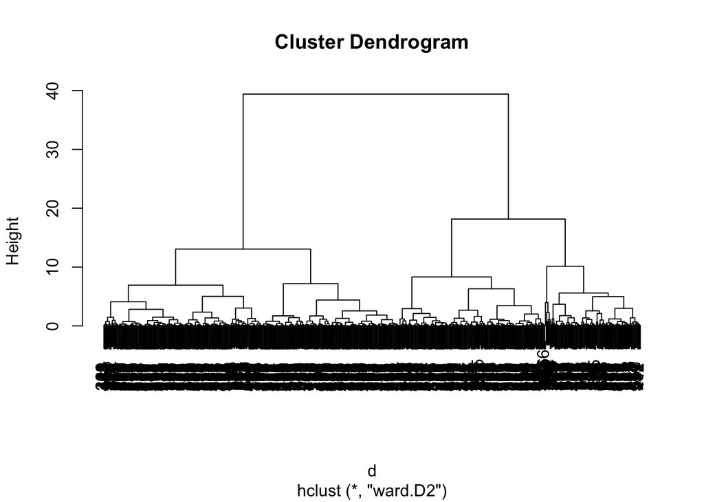

```r
plot (hc)
```

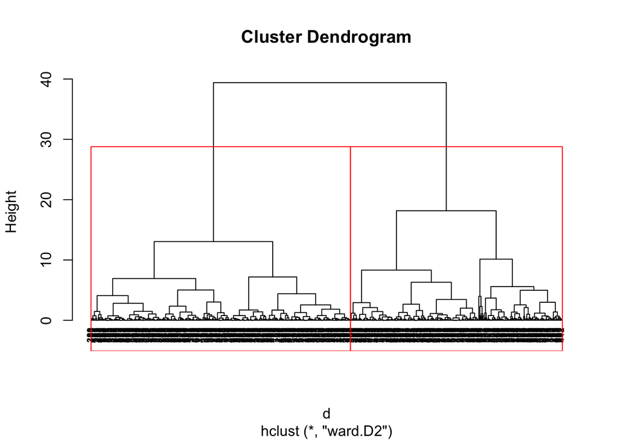

```r
plot(hc, hang = -2, cex = 0.6)
hc$labels <- x_std$Weight_sc
rect.hclust(hc, k = 2, border = "red")
```

```r
gruppen <- cutree(hc, k = 2)
```

## d

```r
x_std$gender_ward <- gruppen
```

## e

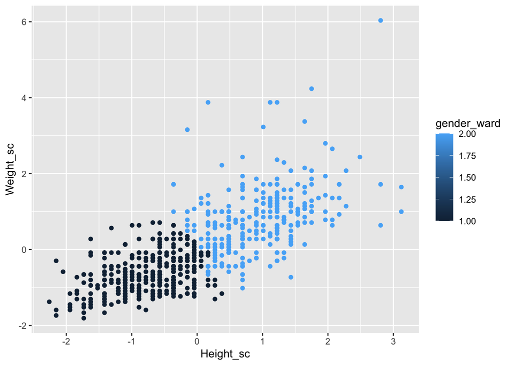

```r
ggplot(x_std,
       aes(Height_sc, Weight_sc, color = gender_ward)) +
  geom_point()
```

Das Scatterplot wird in die zwei Cluster unterteilt, die hier farbig zum Vorschein kommen. Der Verlauf (Richtung) des Scatterplots ist positiv. Art: linear, da die Werte auf beiden Achsen zunehmen. Stärke: geringe Streuung der Werte.

# Compare results

## a

### 1

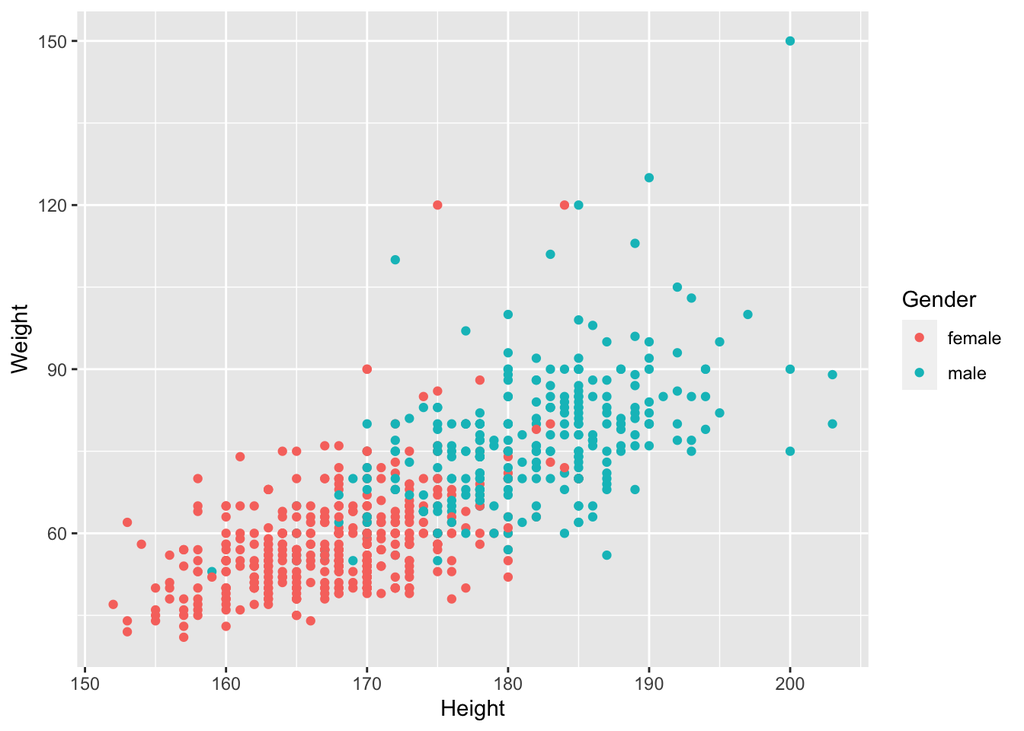

```r
ggplot(df_1,
       aes(Height, Weight, color = Gender)) +
  geom_point()
```

### 2

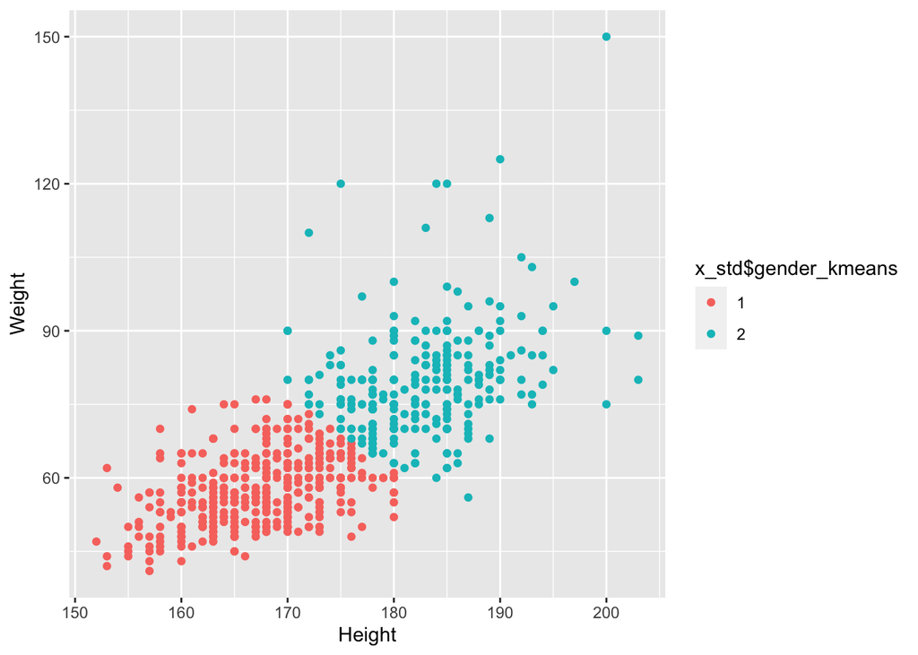

```r
ggplot(df_1,
       aes(Height, Weight, color = x_std$gender_kmeans)) +
  geom_point()
```

### 3

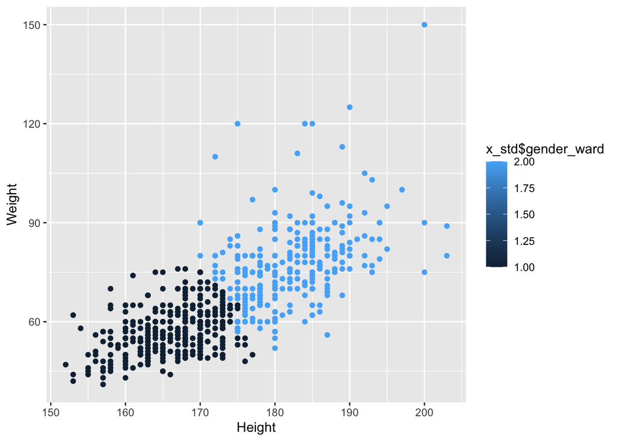

```r
ggplot(df_1,
       aes(Height, Weight, color = x_std$gender_ward)) +
  geom_point()
```

K-Means-Clustering ist ein schneller, robuster und einfacher Algorithmus, der zuverlässige Ergebnisse liefert, wenn die Datensätze sich voneinander unterscheiden.Er wird am besten verwendet, wenn die Anzahl der Clusterzentren aufgrund einer gut definierten Liste von Typen, die in den Daten angezeigt werden, spezifiziert ist. Es ist jedoch zu bedenken, dass das K-Means-Clustering möglicherweise nicht gut funktioniert, wenn es z.B. stark überlappende Daten enthält oder diese voller Ausreißer sind. k-means eine hervorragende Lösung für das Pre-Clustering, da es den Platz in kleinere Unterräume reduziert, in denen andere Clustering-Algorithmen angewendet werden können. Ward Methode nutzt keine random Starting Points, das Ergebnis ist also eindeutig und das Verfahren wird meistens dann veerwendet, wenn es keine Ausreißer gibt und die Cluster ungefährt gleich groß sein sollen.

Die Ward Methode hat in unserem Fall mehr Männer erreichen können und hat einen deutlich härteren Cut gemacht als kmeans. kmeans hat die zwei Cluster so unterteilt, dass die größeren Ausreißer der Frauen einfach dem 2. Cluster zugeordnet wurden.

Aufgrund der Menge der Daten und der leichten Cluster Bestimmung tendieren wir zu kmeans, da man bei der kmeans Analyse mehr Frauen Daten visualisert hat.

# Finalize data

```r
df_3 <- x_std %>%
  filter(gender_kmeans == "1")
```